```python
'''

How to hide code from cells in ipython notebook visualized with nbviewer?
url: https://stackoverflow.com/questions/27934885/how-to-hide-code-from-cells-in-ipython-notebook-visualized-with-nbviewer

'''

from IPython.display import HTML

HTML('''<script>
code_show=true;
function code_toggle() {
 if (code_show){
 $('div.input').hide();
 } else {
 $('div.input').show();
 }
 code_show = !code_show
}
$( document ).ready(code_toggle);
</script>
<form action="javascript:code_toggle()"><input type="submit" value="Click here to toggle on/off the raw code."></form>''')
```

```python
#!/usr/bin/python

import numpy as np
from sklearn.metrics import accuracy_score
from sklearn.metrics import precision_score
from sklearn.metrics import recall_score
from sklearn.metrics import confusion_matrix
import seaborn as sns
import matplotlib.pyplot as plt
%matplotlib inline

def featureFormat( dictionary, features, remove_NaN=True, remove_all_zeroes=False, remove_any_zeroes=False, sort_keys = 'C:/Users/Dewi Octavia/Documents/machinelearning_tools/python2_lesson14_keys.pkl'):
    """ convert dictionary to numpy array of features
        remove_NaN = True will convert "NaN" string to 0.0
        remove_all_zeroes = True will omit any data points for which
            all the features you seek are 0.0
        remove_any_zeroes = True will omit any data points for which
            any of the features you seek are 0.0
        sort_keys = True sorts keys by alphabetical order. Setting the value as
            a string opens the corresponding pickle file with a preset key
            order (this is used for Python 3 compatibility, and sort_keys
            should be left as False for the course mini-projects).
        NOTE: first feature is assumed to be 'poi' and is not checked for
            removal for zero or missing values.
    """


    return_list = []

    # Key order - first branch is for Python 3 compatibility on mini-projects,
    # second branch is for compatibility on final project.
    if isinstance(sort_keys, str):
        import pickle
        keys = pickle.load(open(sort_keys, "rb"))
    elif sort_keys:
        keys = sorted(dictionary.keys())
    else:
        keys = dictionary.keys()

    for key in keys:
        tmp_list = []
        for feature in features:
            #if feature != 'email_address':
            try:
                dictionary[key][feature]
            except KeyError:
                print "error: key ", feature, " not present"
                return
            value = dictionary[key][feature]
            if value=="NaN" and remove_NaN:
                value = 0
            tmp_list.append( float(value) )

        # Logic for deciding whether or not to add the data point.
        append = True
        # exclude 'poi' class as criteria.
        if features[0] == 'poi':
            test_list = tmp_list[1:]
        else:
            test_list = tmp_list
        ### if all features are zero and you want to remove
        ### data points that are all zero, do that here
        if remove_all_zeroes:
            append = False
            for item in test_list:
                if item != 0 and item != "NaN":
                    append = True
                    break
        ### if any features for a given data point are zero
        ### and you want to remove data points with any zeroes,
        ### handle that here
        if remove_any_zeroes:
            if 0 in test_list or "NaN" in test_list:
                append = False
        ### Append the data point if flagged for addition.
        if append:
            return_list.append( np.array(tmp_list) )

    return np.array(return_list)


def targetFeatureSplit( data ):
    """
        given a numpy array like the one returned from
        featureFormat, separate out the first feature
        and put it into its own list (this should be the
        quantity you want to predict)

        return targets and features as separate lists

        (sklearn can generally handle both lists and numpy arrays as
        input formats when training/predicting)
    """

    target = []
    features = []
    for item in data:
        target.append( item[0] )
        features.append( item[1:] )

    return target, features


def test_score(clf, dataset, feature_list):
    data = featureFormat(dataset, feature_list, sort_keys = True)
    labels, features = targetFeatureSplit(data)
    cv = StratifiedShuffleSplit(labels, 1000, random_state = 42)

    true_pos = 0
    true_neg = 0
    false_neg = 0
    false_pos = 0
    for train_indices, test_indices in cv:
        features_train = [features[ii] for ii in train_indices]
        features_test = [features[ii] for ii in test_indices]
        labels_train = [labels[ii] for ii in train_indices]
        labels_test = [labels[ii] for ii in test_indices]

        ### fit the classifier using training set, and test on test set
        clf.fit(features_train, labels_train)
        predictions = clf.predict(features_test)

        #accuracy = round(accuracy_score(predictions, labels_test),5)

        for prediction, truth in zip(predictions, labels_test):
            if prediction == 1 and truth == 1:
                true_pos += 1
            elif prediction == 0 and truth == 0:
                true_neg += 1
            elif prediction == 0 and truth == 1:
                false_neg += 1
            elif prediction == 1 and truth == 0:
                false_pos += 1

    if true_pos == 0:
        return (0, 0, 0, accuracy)
    else:
        total_predictions = float(true_pos) + float(true_neg) + float(false_neg) + float(false_pos)
        accuracy = (float(true_pos) + float(true_neg))/total_predictions
        precision = round(float(true_pos)/(float(true_pos) + float(false_pos)),5)
        recall = round(float(true_pos)/(float(true_pos) + float(false_neg)), 5)
        f1 = round(2*float(true_pos)/(2*float(true_pos) + float(false_pos)+ float(false_neg)),5)

        #print total_predictions, true_pos, false_pos, false_neg, true_neg
        return (accuracy, precision, recall, f1)

    #===========================================================
    ## Compute confusion matrix
    #model = clf
    #cm = confusion_matrix(labels_test.values, model.predict(features_test))
    #
    ## view with a heatmap
    #sns.heatmap(cm, annot=True, cmap='Blues', xticklabels=['no', 'yes'], yticklabels=['no', 'yes'])
    #plt.ylabel('True label')
    #plt.xlabel('Predicted label')
    #plt.title('Confusion matrix for:\n{}'.format(model.__class__.__name__));
```

```python
# tester.py
#!/usr/bin/pickle

""" a basic script for importing student's POI identifier,
    and checking the results that they get from it

    requires that the algorithm, dataset, and features list
    be written to my_classifier.pkl, my_dataset.pkl, and
    my_feature_list.pkl, respectively

    that process should happen at the end of poi_id.py
"""

import pickle
import sys
from sklearn.cross_validation import StratifiedShuffleSplit
#sys.path.append("../tools/")
#from feature_format import featureFormat, targetFeatureSplit

PERF_FORMAT_STRING = "\
\tAccuracy: {:>0.{display_precision}f}\tPrecision: {:>0.{display_precision}f}\t\
Recall: {:>0.{display_precision}f}\tF1: {:>0.{display_precision}f}\tF2: {:>0.{display_precision}f}"
RESULTS_FORMAT_STRING = "\tTotal predictions: {:4d}\tTrue positives: {:4d}\tFalse positives: {:4d}\
\tFalse negatives: {:4d}\tTrue negatives: {:4d}"

def test_classifier(clf, dataset, feature_list, folds = 1000):
    data = featureFormat(dataset, feature_list, sort_keys = True)
    labels, features = targetFeatureSplit(data)
    cv = StratifiedShuffleSplit(labels, folds, random_state = 42)
    true_negatives = 0
    false_negatives = 0
    true_positives = 0
    false_positives = 0
    for train_idx, test_idx in cv:
        features_train = []
        features_test  = []
        labels_train   = []
        labels_test    = []
        for ii in train_idx:
            features_train.append( features[ii] )
            labels_train.append( labels[ii] )
        for jj in test_idx:
            features_test.append( features[jj] )
            labels_test.append( labels[jj] )

        ### fit the classifier using training set, and test on test set
        clf.fit(features_train, labels_train)
        predictions = clf.predict(features_test)
        for prediction, truth in zip(predictions, labels_test):
            if prediction == 0 and truth == 0:
                true_negatives += 1
            elif prediction == 0 and truth == 1:
                false_negatives += 1
            elif prediction == 1 and truth == 0:
                false_positives += 1
            elif prediction == 1 and truth == 1:
                true_positives += 1
            else:
                print "Warning: Found a predicted label not == 0 or 1."
                print "All predictions should take value 0 or 1."
                print "Evaluating performance for processed predictions:"
                break
    try:
        total_predictions = true_negatives + false_negatives + false_positives + true_positives
        accuracy = 1.0*(true_positives + true_negatives)/total_predictions
        precision = 1.0*true_positives/(true_positives+false_positives)
        recall = 1.0*true_positives/(true_positives+false_negatives)
        f1 = 2.0 * true_positives/(2*true_positives + false_positives+false_negatives)
        f2 = (1+2.0*2.0) * precision*recall/(4*precision + recall)
        print clf
        print PERF_FORMAT_STRING.format(accuracy, precision, recall, f1, f2, display_precision = 5)
        print RESULTS_FORMAT_STRING.format(total_predictions, true_positives, false_positives, false_negatives, true_negatives)
        print ""
    except:
        print "Got a divide by zero when trying out:", clf
        print "Precision or recall may be undefined due to a lack of true positive predicitons."

CLF_PICKLE_FILENAME = "my_classifier.pkl"
DATASET_PICKLE_FILENAME = "my_dataset.pkl"
FEATURE_LIST_FILENAME = "my_feature_list.pkl"


def dump_classifier_and_data(clf, dataset, feature_list):
    with open(CLF_PICKLE_FILENAME, "w") as clf_outfile:
        pickle.dump(clf, clf_outfile)
    with open(DATASET_PICKLE_FILENAME, "w") as dataset_outfile:
        pickle.dump(dataset, dataset_outfile)
    with open(FEATURE_LIST_FILENAME, "w") as featurelist_outfile:
        pickle.dump(feature_list, featurelist_outfile)

def load_classifier_and_data():
    with open(CLF_PICKLE_FILENAME, "r") as clf_infile:
        clf = pickle.load(clf_infile)
    with open(DATASET_PICKLE_FILENAME, "r") as dataset_infile:
        dataset = pickle.load(dataset_infile)
    with open(FEATURE_LIST_FILENAME, "r") as featurelist_infile:
        feature_list = pickle.load(featurelist_infile)
    return clf, dataset, feature_list

def main():
    ### load up student's classifier, dataset, and feature_list
    clf, dataset, feature_list = load_classifier_and_data()
    ### Run testing script
    test_classifier(clf, dataset, feature_list)

#if __name__ == '__main__':
#    main()
```

# Project Overview

In this project, machine learning algorithm will be deployed to identify fraud from Enron financial and email features, with the goal to minimise missed frauds and false alarms. Machine learning is useful in this project as it could detect unusual pattern in either financial and/or email datasets, which effectively can be used to uncover fraudulent as soon as it happens in the future.

# 1. Understanding the Dataset and Question

## 1.1 Data Exploration

### Data features

Each person in the dataset has 21 features available. The features in Enron dataset fall into three major types, they are financial features, email features and POI labels.

financial features:

- salary
- bonus
- long_term_incentive
- deferred_income
- deferral_payments
- loan_advances
- other
- expenses
- director_fees
- total_payments
- exercised_stock_options
- restricted_stock
- restricted_stock_deferred
- total_stock_value

email features:

- to_messages
- from_poi_to_this_person
- from_messages
- from_this_person_to_poi
- shared_receipt_with_poi
- email_address

POI labels: poi

```python
financial_features = ['salary',
                      'bonus',
                      'long_term_incentive',
                      'deferred_income',
                      'deferral_payments',
                      'loan_advances',
                      'other',
                      'expenses',
                      'director_fees',
                      'total_payments',
                      'exercised_stock_options',
                      'restricted_stock',
                      'restricted_stock_deferred',
                      'total_stock_value']


email_features = ['to_messages',
                  'from_poi_to_this_person',
                  'from_messages',
                  'from_this_person_to_poi',
                  'shared_receipt_with_poi',
                  'email_address']

poi = ['poi']

features_list = poi + financial_features + email_features
```

### Total number of data points

```python
import pickle

data_dict = pickle.load(open("C:/Users/Dewi Octavia/Documents/p5_final_project/final_project_dataset.pkl", "r"))

print "Total number of data points: ", len(data_dict)
```

```
Total number of data points:  146
```

### Allocation across classes (POI/non-POI)

```python
count_poi = 0
count_nonpoi = 0
poi_names = []

for name in data_dict.keys():
    if data_dict[name]['poi'] == True:
        count_poi += 1
        poi_names.append(name)
    else:
        count_nonpoi += 1

print "Allocation of POI/non-POI :", count_poi, '/', count_nonpoi
```

```
Allocation of POI/non-POI : 18 / 128
```

### Features with missing values

The list of 'NaN' value in each features is as follows:

```python
import texttable

#t = texttable.Texttable()
#t.set_cols_width([20, 15, 22, 25])
#t.add_row(['FEATURES', 'NUMBERS OF NaN', 'NUMBERS OF NaN IN POI', 'POI NAMES'])

t_nan = texttable.Texttable()
t_nan.set_cols_width([20, 15, 22, 25])
t_nan.add_row(['FEATURES', 'NUMBERS OF NaN', 'NUMBERS OF NaN IN POI', 'POI NAMES'])

for feature in features_list:
    if feature != 'poi':
        count_nan = 0
        count_nan_poi = 0
        feature_poinames = []
        ffeature_poinames = []
        not_in_poi = []

        for name in data_dict.keys():
            if data_dict[name][feature] == 'NaN':
                count_nan += 1

                if data_dict[name]['poi'] == True:
                    count_nan_poi += 1
                    feature_poinames.append(name)

                    if count_nan_poi <= 10:
                        ffeature_poinames = feature_poinames
                    elif count_nan_poi == 18:
                        ffeature_poinames = 'All POIs'
                    elif count_nan_poi > 10 & count_nan_poi <18:
                        not_in_poi = list(set(poi_names) - set(feature_poinames))
                        ffeature_poinames = 'All NaN except ' + str(len(not_in_poi)) + ': ' + ', '.join(not_in_poi)


        t_nan.add_row([feature, count_nan, count_nan_poi, str(ffeature_poinames)])

print t_nan.draw()
```

```
+----------------------+-----------------+------------------------+---------------------------+
| FEATURES             | NUMBERS OF NaN  | NUMBERS OF NaN IN POI  | POI NAMES                 |
+----------------------+-----------------+------------------------+---------------------------+
| salary               | 51              | 1                      | ['HIRKO JOSEPH']          |
+----------------------+-----------------+------------------------+---------------------------+
| bonus                | 64              | 2                      | ['YEAGER F SCOTT', 'HIRKO |
|                      |                 |                        | JOSEPH']                  |
+----------------------+-----------------+------------------------+---------------------------+
| long_term_incentive  | 80              | 6                      | ['COLWELL WESLEY',        |
|                      |                 |                        | 'RIEKER PAULA H', 'SHELBY |
|                      |                 |                        | REX', 'BELDEN TIMOTHY N', |
|                      |                 |                        | 'YEAGER F SCOTT', 'HIRKO  |
|                      |                 |                        | JOSEPH']                  |
+----------------------+-----------------+------------------------+---------------------------+
| deferred_income      | 97              | 7                      | ['KOPPER MICHAEL J',      |
|                      |                 |                        | 'DELAINEY DAVID W',       |
|                      |                 |                        | 'SKILLING JEFFREY K',     |
|                      |                 |                        | 'YEAGER F SCOTT', 'HIRKO  |
|                      |                 |                        | JOSEPH', 'KOENIG MARK E', |
|                      |                 |                        | 'GLISAN JR BEN F']        |
+----------------------+-----------------+------------------------+---------------------------+
| deferral_payments    | 107             | 13                     | All NaN except 5: HIRKO   |
|                      |                 |                        | JOSEPH, LAY KENNETH L,    |
|                      |                 |                        | COLWELL WESLEY, BELDEN    |
|                      |                 |                        | TIMOTHY N, RIEKER PAULA H |
+----------------------+-----------------+------------------------+---------------------------+
| loan_advances        | 142             | 17                     | All NaN except 1: LAY     |
|                      |                 |                        | KENNETH L                 |
+----------------------+-----------------+------------------------+---------------------------+
| other                | 53              | 0                      | []                        |
+----------------------+-----------------+------------------------+---------------------------+
| expenses             | 51              | 0                      | []                        |
+----------------------+-----------------+------------------------+---------------------------+
| director_fees        | 129             | 18                     | All POIs                  |
+----------------------+-----------------+------------------------+---------------------------+
| total_payments       | 21              | 0                      | []                        |
+----------------------+-----------------+------------------------+---------------------------+
| exercised_stock_opti | 44              | 6                      | ['COLWELL WESLEY',        |
| ons                  |                 |                        | 'KOPPER MICHAEL J',       |
|                      |                 |                        | 'BOWEN JR RAYMOND M',     |
```

[output cut: 23 more lines]

```
|                      |                 |                        | 'YEAGER F SCOTT', 'HIRKO  |
|                      |                 |                        | JOSEPH']                  |
+----------------------+-----------------+------------------------+---------------------------+
| from_this_person_to_ | 60              | 4                      | ['KOPPER MICHAEL J',      |
| poi                  |                 |                        | 'FASTOW ANDREW S',        |
|                      |                 |                        | 'YEAGER F SCOTT', 'HIRKO  |
|                      |                 |                        | JOSEPH']                  |
+----------------------+-----------------+------------------------+---------------------------+
| shared_receipt_with_ | 60              | 4                      | ['KOPPER MICHAEL J',      |
| poi                  |                 |                        | 'FASTOW ANDREW S',        |
|                      |                 |                        | 'YEAGER F SCOTT', 'HIRKO  |
|                      |                 |                        | JOSEPH']                  |
+----------------------+-----------------+------------------------+---------------------------+
| email_address        | 35              | 0                      | []                        |
+----------------------+-----------------+------------------------+---------------------------+
```

The findings arose from the NaN summary table above are:

1. Every POIs has their own email address but there is no email record of 4 POIs.
2. All POIs have expenses, "other" finance, total payments and total stock value records.
3. All POIs have no director fee and restricted stock deferred records
4. Ken Lay is the only POI with loan advances
5. The names of 2 POIs, Hirko Joseph and Yeager F Scott have appeared more often than others. Hirko Joseph has no salary and bonus records and a lot of NaN values other than deferral payments, other, expenses and exercised stock options.

At this stage all NaN values are converted to 0.

```python
# Remove email address from features_list for data conversion to numpy array in featureFormat:
del features_list[-1]

#if "email_address" not in features_list:
#    print "email_address has been removed from features_list!"
#else:
#    print "email_address needs to be removed from features_list!"
```

## 1.2 Outlier Investigation

### Outlier

In order to spot outliers in the dataset, we need data visualisation, bonus vs salary is plotted for this purpose as shown below.

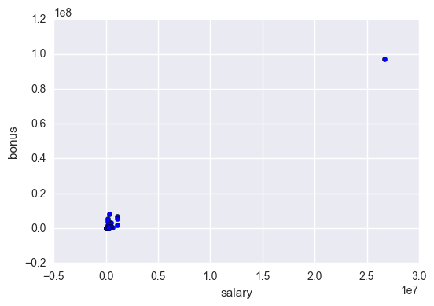

```python
import matplotlib.pyplot as plt
%matplotlib inline

data = featureFormat( data_dict, features_list )

for point in data:
    salary = point[1]
    bonus = point[2]
    plt.scatter( salary, bonus )

plt.xlabel("salary")
plt.ylabel("bonus")
plt.show()


# Another way to find outlier in salary and bonus using pandas
# import pandas

#df = pandas.DataFrame.from_dict(data_dict, orient = 'index', dtype = np.float)
#print df.describe().loc[:,['salary', 'bonus']]
```

There is one out-of-place data point spotted! The bonus and salary values are way higher than others so we just need to find the maximum salary (or bonus) in order to identify and subsequently remove this data point.

```python
import numpy as np

max_salary = max(data[:, 1])

outlier_index = np.where(data[:,1] == max_salary)

print 'Outlier found and removed'
print 'Name: ', data_dict.keys()[int(outlier_index[0])]
print 'Salary: ', data_dict[data_dict.keys()[int(outlier_index[0])]]['salary']

# remove data point 'TOTAL'
data_dict.pop("TOTAL",None)

data = featureFormat( data_dict, features_list, sort_keys = False )

print "There is now", len(data_dict), "data points left in dataset."
```

```
Outlier found and removed
Name:  TOTAL
Salary:  26704229
There is now 145 data points left in dataset.
```

### Auditing financial features

The next step is auditing the financial features to ensure the numbers do add up. From the summary payment document ("enron61702insiderpay.pdf"), total_payments is the sum of salary, bonus, long_term_incentive, deferred_income, deferral_payments, loan_advances, other, expenses and director_fees. Total_stock_value is the sum of exercised_stock_options, restricted_stock and restricted_stock_deferred.

```python
# Audit financial features.
# total_payments = salary + bonus + long_term_incentive + deferred_income +
#                  deferral_payments + loan_advances + other + expenses + director_fees

from pprint import pprint

def audit_finance_data(data_dict):
    data = featureFormat( data_dict, features_list, sort_keys = False )
    payment_count = 0
    stock_count = 0

    for i in range(len(data_dict)):
        if sum(data[i][1:10]) != data[i][10]:
            payment_count += 1
            print "\n Unbalanced payment account:"
            print payment_count, " - index = ", i, data_dict.keys()[i]
            print "calc total payment = ", sum(data[i][1:10])
            print "total payments = ", data[i][10]
            pprint , data_dict.values()[i]
            print "data : ", data[i][1:11]

    for i in range(len(data_dict)):
        if sum(data[i][11:14]) != data[i][14]:
            stock_count += 1
            print "\n Unbalanced stock account: "
            print stock_count, " - index = ", i, data_dict.keys()[i]
            print "calc total stock = ", sum(data[i][11:13])
            print "total stock = ", data[i][14]

audit_finance_data(data_dict)

# Findings
# BELFER ROBERT's data is right-shifted from 'deferred income'
# BHATNAGAR SANJAY's data is left-shifted from 'Other'
```

```
 Unbalanced payment account:
1  - index =  24 BELFER ROBERT
calc total payment =  -99215.0
total payments =  102500.0
data :  [      0.       0.       0.       0. -102500.       0.       0.       0.
    3285.  102500.]

 Unbalanced payment account:
2  - index =  117 BHATNAGAR SANJAY
calc total payment =  275728.0
total payments =  15456290.0
data :  [        0.         0.         0.         0.         0.         0.
    137864.         0.    137864.  15456290.]

 Unbalanced stock account:
1  - index =  24 BELFER ROBERT
calc total stock =  3285.0
total stock =  -44093.0

 Unbalanced stock account:
2  - index =  117 BHATNAGAR SANJAY
calc total stock =  0.0
total stock =  0.0
```

It was found that the accounts of Belfer Robert and Bhatnagar Sanjay did not add up. After going through 'enron61702insiderpay.pdf' manually, it seemed to be some data entry problem. Belfer Robert's data was right-shifted from 'deferred income' and Bhatnagar Sanjay's was left-shifted from 'Other'. The two accounts are then corrected and re-audited.

```python
# Correcting BELFER ROBERT and BHATNAGAR SANJAY's data in data_dict

# BELFER ROBERT's data
data_dict['BELFER ROBERT']['deferred_income'] = -102500
data_dict['BELFER ROBERT']['deferral_payments'] = 'NaN'
data_dict['BELFER ROBERT']['expenses'] = 3285
data_dict['BELFER ROBERT']['director_fees'] = 102500
data_dict['BELFER ROBERT']['total_payments'] = 3285
data_dict['BELFER ROBERT']['exercised_stock_options'] = 'NaN'
data_dict['BELFER ROBERT']['restricted_stock'] = 44093
data_dict['BELFER ROBERT']['restricted_stock_deferred'] = -44093
data_dict['BELFER ROBERT']['total_stock_value'] = 'NaN'


# BHATNAGAR SANJAY's data
data_dict['BHATNAGAR SANJAY']['other'] = 'NaN'
data_dict['BHATNAGAR SANJAY']['expenses'] = 137864
data_dict['BHATNAGAR SANJAY']['director_fees'] = 'NaN'
data_dict['BHATNAGAR SANJAY']['total_payments'] = 137864
data_dict['BHATNAGAR SANJAY']['exercised_stock_options'] = 15456290
data_dict['BHATNAGAR SANJAY']['restricted_stock'] = 2604490
data_dict['BHATNAGAR SANJAY']['restricted_stock_deferred'] = -2604490
data_dict['BHATNAGAR SANJAY']['total_stock_value'] = 15456290


audit_finance_data(data_dict)
```

# 2. Optimize Feature Selection/Engineering

## 2.1 Adding New Features

The available information in email features can be used to calculate the fraction of emails to and from POIs, which could useful as we expect correspondence rate among POIs is higher than to non-POI's.

```
features_list:
['poi',
 'salary',
 'bonus',
 'long_term_incentive',
 'deferred_income',
 'deferral_payments',
 'loan_advances',
 'other',
 'expenses',
 'director_fees',
 'total_payments',
 'exercised_stock_options',
 'restricted_stock',
 'restricted_stock_deferred',
 'total_stock_value',
 'to_messages',
 'from_poi_to_this_person',
 'from_messages',
 'from_this_person_to_poi',
 'shared_receipt_with_poi',
 'fraction_from_poi',
 'fraction_to_poi']
```

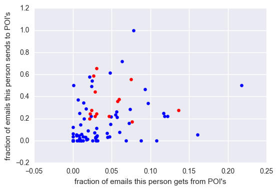

```python
import matplotlib
import matplotlib.pyplot as plt
% matplotlib inline


def computeFraction( poi_messages, all_messages ):
    """ given a number messages to/from POI (numerator)
        and number of all messages to/from a person (denominator),
        return the fraction of messages to/from that person
        that are from/to a POI
   """

    if poi_messages == 'NaN' or all_messages == 'NaN':
        fraction = 0
    else:
        fraction = float(poi_messages)/float(all_messages)

    return fraction



submit_dict = {}
for name in data_dict:

    data_point = data_dict[name]

    #print name
    from_poi_to_this_person = data_point["from_poi_to_this_person"]
    to_messages = data_point["to_messages"]
    shared_receipt_with_poi = data_point["shared_receipt_with_poi"]
    #total_from_poi = from_poi_to_this_person + shared_receipt_with_poi
    fraction_from_poi = computeFraction( from_poi_to_this_person, to_messages )
    #print "fraction_from_poi = ", fraction_from_poi
    data_point["fraction_from_poi"] = fraction_from_poi


    from_this_person_to_poi = data_point["from_this_person_to_poi"]
    from_messages = data_point["from_messages"]
    fraction_to_poi = computeFraction( from_this_person_to_poi, from_messages )
    #print "fraction_to_poi = ", fraction_to_poi
    submit_dict[name]={"from_poi_to_this_person":fraction_from_poi,
                       "from_this_person_to_poi":fraction_to_poi}
    data_point["fraction_to_poi"] = fraction_to_poi

for name in submit_dict.keys():
    if data_dict[name]["poi"] == True:
        plt.scatter(submit_dict[name]['from_poi_to_this_person'], submit_dict[name]['from_this_person_to_poi'], color = "red")
    else:
        plt.scatter(submit_dict[name]['from_poi_to_this_person'], submit_dict[name]['from_this_person_to_poi'], color = "blue")
        plt.xlabel("fraction of emails this person gets from POI's")
        plt.ylabel("fraction of emails this person sends to POI's")


# Add new features into features_list

features_list = features_list  + ['fraction_from_poi', 'fraction_to_poi']
print "features_list: "
pprint(features_list)
```

From the plot above, POI's are represented in red and non-POI's in blue. It shows that if less than 20% of emails a person send are sent to POI, that person is almost certainly not a POI. There is also a lot of non-POI's with high email ratio sent to POI's which I think is common for employees in executive level to have high correspondence rate among themselves.

Reviewer has pointed out that using email data with POI information as features to train machine learning algorithm has data leakage problem as the email data contains the information we are trying to predict. In building machine learning model outside this project, this should be avoided.

```python
### Store to my_dataset for easy export below.
my_dataset = data_dict
```

## 2.2 Feature Selection and Feature Scaling

In this feature selection step, all original features (except email_address) and two new features are fed into SelectKBest for an automated feature selection. A list of machine learning algorithms will be tested to find a trained model. The algorithms tested are:

1. Naive Bayes
2. Logistic Regression
3. Decision Tree
4. k-Nearest Neighbors
5. AdaBoost
6. Random Forest.

For the algorithms like Logistic Regression and k-Nearest Neighbors, which feature scaling matters, the data is scaled using MinMaxScaler before it is fed into SelectKBest [http://sebastianraschka.com/Articles/2014_about_feature_scaling.html].

In each model, the best tuning parameters will be obtained using GridSearchCV, cross validated as it goes and evaluated based on F1-score metric. The best score of each models will then be compared.

The full results of each algortihms can be found in: P5_results_all.txt

```python
### Apply Scaling to algorithms that call for

separator = '=============================================================================================='

import warnings
warnings.filterwarnings("ignore")

from collections import OrderedDict
from time import time
from pprint import pprint
from sklearn.cross_validation import train_test_split
from sklearn.preprocessing import MinMaxScaler, StandardScaler
from sklearn.svm import SVC, LinearSVC
from sklearn.tree import DecisionTreeClassifier
from sklearn.neighbors import KNeighborsClassifier
from sklearn.naive_bayes import GaussianNB
from sklearn.ensemble import RandomForestClassifier
from sklearn.ensemble import AdaBoostClassifier
from sklearn.linear_model import LogisticRegression
from sklearn.feature_selection import SelectKBest, chi2, f_classif
from sklearn.pipeline import Pipeline, make_pipeline
from sklearn.cross_validation import StratifiedShuffleSplit
from sklearn.model_selection import GridSearchCV
from sklearn.metrics import classification_report
import pandas as pd
from sklearn.metrics import accuracy_score, f1_score, precision_score, recall_score
from sklearn.metrics import classification_report, confusion_matrix
pd.set_option('display.max_colwidth', 0)

# Initiate a list to store results
results = []

# Convert my_dataset values to absolute values
for name in my_dataset:
    for feature in ['deferred_income', 'restricted_stock_deferred'] :
        if my_dataset[name][feature] != 'NaN':
            my_dataset[name][feature] = abs(int(my_dataset[name][feature]))




classifiers_list = [('NaiveBayes', GaussianNB()),
                    ('LogisticRegression', LogisticRegression()),
                    ('DecisionTree', DecisionTreeClassifier()),
                    ('KNN', KNeighborsClassifier()),
                    ('AdaBoost', AdaBoostClassifier()),
                    ('RandomForest', RandomForestClassifier())
                    ]


classifiers_list = OrderedDict(classifiers_list)

# Initiate table to compile test scores
t = texttable.Texttable()
t.set_cols_width([25, 15, 15, 15, 15])
t.add_row(['CLASSIFIERS', 'ACCURACY', 'PRECISION', 'RECALL', 'F1' ])

score_list = []
bigscore_list = []
all_list_precision = []
all_list_recall = []
all_list_f1 = []

for i, item in enumerate(classifiers_list):
    t0 = time()
    #print "\n\n", i, item
    estimator = classifiers_list.values()[i]

    data = featureFormat(my_dataset, features_list, sort_keys = True)

    # Apply feature scaling on LR and KNN
    if item in ['LogisticRegression', 'KNN']:
        data = MinMaxScaler().fit_transform(data)

    labels, features = targetFeatureSplit(data)

    features_train, features_test, labels_train, labels_test =  train_test_split(
        features,
        labels,
        test_size=0.3,
        random_state=42,
        stratify=labels
        )

    # Make an StratifiedShuffleSplit iterator for cross-validation in GridSearchCV

    sss = StratifiedShuffleSplit(
        labels,
        n_iter = 20,
        test_size = 0.5,
        random_state = 42
        )

    pipeline = make_pipeline(
        SelectKBest(),
        estimator)

    pipeline_steps = []

    for i in range(len(pipeline.steps)):
        pipeline_steps.append(pipeline.steps[i][0])

    all_params = OrderedDict([
            ('selectkbest__k', [3, 4, 5, 6, 7, 8, 9, 10, 11, 12, 13, 14, 15]),
            ('selectkbest__score_func', [f_classif, chi2]),
            ('decisiontreeclassifier__min_samples_split', [2,5,10,15,25,50]),
            ('decisiontreeclassifier__criterion', ('gini', 'entropy')),
            #('decisiontreeclassifier__max_depth', [1,2,3,4,5,6]),
            #('decisiontreeclassifier__min_samples_leaf', [4,5,6,7,8]),
            ('decisiontreeclassifier__random_state', [42]),
            ('kneighborsclassifier__n_neighbors', [3,5,7,9]),
            ('kneighborsclassifier__weights', ('uniform', 'distance')),
            ('kneighborsclassifier__algorithm', ('ball_tree', 'kd_tree', 'brute', 'auto')),
            ('kneighborsclassifier__p', [1,2]),
            ('adaboostclassifier__base_estimator', [DecisionTreeClassifier()]),
            ('adaboostclassifier__n_estimators', [5, 10, 50, 100, 150]),
            ('adaboostclassifier__algorithm', ('SAMME', 'SAMME.R')),
            ('adaboostclassifier__learning_rate', [0.001, 0.1, 0.5, 1, 1.5, 2]),
            ('adaboostclassifier__random_state', [42]),
            ('randomforestclassifier__n_estimators', [2, 3, 5, 8]),
            ('randomforestclassifier__criterion', ('gini', 'entropy')),
            ('randomforestclassifier__min_samples_split', [2,5,10,15,25,50,80,100]),
            ('logisticregression__penalty', ('l1', 'l2')),
            ('logisticregression__C', [0.001, 0.1, 1, 10, 100]),
            ('logisticregression__fit_intercept', [True]),
            ('logisticregression__class_weight', ['balanced']),
            ('logisticregression__intercept_scaling', [0.5, 1.0, 1.5]),
            ('logisticregression__n_jobs', [-1])
        ])


    # Dictionary of tuning parameter is built based on classifier
    grid_params = {}

    for step in pipeline_steps:
        for parameter in all_params:
            step_in_parameter = parameter.split('__')[0]

            if step_in_parameter == step:
                grid_params[parameter] = all_params[parameter]

    #-print "\n grid_params: ", grid_params

    scores = ['precision', 'recall', 'f1']

    # store precision, recall and F1 scores for every parameter combos into bigscore_list
    for score in scores:
        #print("# Parameters Tuning for %s" % score)
        clf = GridSearchCV(pipeline,
                           grid_params,
                           verbose = 0,
                           cv = sss,
                           scoring=score
                          )

        gs_clf = clf.fit(features, labels)


        means = gs_clf.cv_results_['mean_test_score']
        params = gs_clf.cv_results_['params']

        bigscore = zip([item]*means.size, [score]*means.size ,means, params)
        bigscore_list.append(bigscore)


        if score == 'f1':
            best_estimator = gs_clf.best_estimator_
            #print "\n Best estimator gs_clf = ", best_estimator

            # Find features_selected
            features_k = clf.best_params_['selectkbest__k']
            score_func = clf.best_params_['selectkbest__score_func']

            SKB_k = SelectKBest(score_func = score_func, k = features_k)
            SKB_k.fit_transform(features_train, labels_train)


            # Features selected from SelectKBest
            features_selected=[features_list[1:][i]for i in SKB_k.get_support(indices=True)]
            #-print "\n Selected features are: ", features_selected, "\n"


            # SelectKBest Score Summary
            #-print "\n Score Summary:"
            KBest_scores =  [(feature, round(score,3), round(p,3))
                             for feature, score, p in zip(features_list[1:], SKB_k.scores_, SKB_k.pvalues_)]
            KBest_scores = pd.DataFrame.from_records(KBest_scores, index = "feature",
                                       columns=['feature', 'score', 'p-value'])

            KBest_scores.sort_values(by = 'score', ascending = False, inplace = True)
            #-print "KBest_scores: \n", KBest_scores, "\n\n"


            # compile my_features_list
            my_features_list = ['poi'] + features_selected


            # Assign best_estimator from SelectKBest to clf and have it tested
            clf = clf.best_estimator_
            #print 'Best params from clf: \n', clf, "\n"

            # Feature Importance for Decision Tree Classifier
            if item == 'DecisionTree':
                importances = clf.named_steps['decisiontreeclassifier'].feature_importances_
                importances_sort = sorted(importances, reverse = True)
                importances_table = [(feature, round(importance,3))
                                     for feature, importance in zip(KBest_scores.index.values[:(len(importances))], importances_sort)]

                importances_table = pd.DataFrame.from_records(importances_table, index='Feature',
                                                             columns=['Feature', 'Importance Score'])

                importances_table.sort_values(by='Importance Score', ascending=False, inplace =True)



                #-print "\n\n Decision Tree Feature Importances:"
                #-print importances_table, "\n"

            # Test Scores
            score= test_score(clf, my_dataset, my_features_list)
            score_list.append((item, score[0], score[1], score[2], score[3]))
            score_list = sorted(score_list, reverse = True, key=lambda x: x[4])
            #score_list = sorted(score_list, reverse = True, key=lambda x: x[1])

            # Store result of each classififer in scaler_results
            results.append((item, grid_params, clf, features_selected, KBest_scores, score))

    #print "Best params from df :\n", filter_scores_df(bigscore_list)
    #-test_classifier(clf, my_dataset, my_features_list)


    #-print "Time : ", round(time()-t0, 3), "s"
    #-print separator

print "\n\n Classifiers Test Score Summary"
print "=============================="
t.add_rows(score_list, header = False)
print t.draw()

# Save algorithms test scores table
algoTestScore = t
```

```
 Classifiers Test Score Summary
==============================
+---------------------------+-----------------+-----------------+-----------------+-----------------+
| CLASSIFIERS               | ACCURACY        | PRECISION       | RECALL          | F1              |
+---------------------------+-----------------+-----------------+-----------------+-----------------+
| NaiveBayes                | 0.854           | 0.437           | 0.339           | 0.382           |
+---------------------------+-----------------+-----------------+-----------------+-----------------+
| DecisionTree              | 0.843           | 0.394           | 0.327           | 0.357           |
+---------------------------+-----------------+-----------------+-----------------+-----------------+
| KNN                       | 0.867           | 0.504           | 0.231           | 0.316           |
+---------------------------+-----------------+-----------------+-----------------+-----------------+
| LogisticRegression        | 0.651           | 0.212           | 0.597           | 0.313           |
+---------------------------+-----------------+-----------------+-----------------+-----------------+
| RandomForest              | 0.844           | 0.378           | 0.262           | 0.309           |
+---------------------------+-----------------+-----------------+-----------------+-----------------+
| AdaBoost                  | 0.809           | 0.251           | 0.218           | 0.234           |
+---------------------------+-----------------+-----------------+-----------------+-----------------+
```

The findings from the comparison of summary table above are:

1. Naive Bayes and Decision Tree algortihms met the criteria of both precision and recall scores being greater than 0.30.
2. SelectKBest picked up the new feature 'fraction_to_poi' in Naive Bayes classifier which is good.
3. k-Nearest Neighbor model does not meet the passing criteria although it has the highest accuracy and precision scores. However using accuracy as evaluation metric for Enron dataset is not suitable because the dataset is small and skewed. Feature scaling was performed on k-Nearest Neighbors algorithm because it predicts test dataset based on distance measure function. Financial features in dollars are in much larger scale compared to email correspondence features. Scaling all the features to range between 0 and 1 prevents one feature having much higher influence on calculated distance compared to others.
4. Another algorithm that was scaled in this project is Logistic Regression. As mentioned above, the email and financial features are in two different scales, where financial features are in range between thousands to millions and email features between zero to thousands, feature scaling will help speed up gradient descent to reach local minima or minimum cost function [https://mycourses.aalto.fi/pluginfile.php/393629/mod_resource/content/1/Lecture8.pdf].
5. Logistic regression model does not have a good precision, but it has a decent recall. This means when a POI shows up in the test set, the identifier is able to flag the POI quite frequently. The not so good precision means the identifier sometimes also flags non-POI's.
6. AdaBoost-ed Decision Tree, Logistic Regression and Random Forest did not meet the passing criteria.
7. From having the highest F1 score, I would be glad to choose Naive Bayes as my final algorithm. However it does not have tuning parameters therefore Decision Tree with the second highest F1 score is selected as final algorithm instead, for parameter tuning exercise.
8. The final features used in POI identifier consists of four features, they are: 'loan_advances', 'total_payments', 'exercised_stock_options', 'total_stock_value'.

The SelectKBest feature scores of Decision Tree is shown in the table below along with Select KBest Feature Score graph to show the feature score drop and the cutoff:

```python
print results[2][0], "Select KBest Score Table"
results[2][4]
```

```
DecisionTree Select KBest Score Table
```

| feature | score | p-value |
| --- | --- | --- |
| loan_advances | 5.347501e+08 | 0.000 |
| total_stock_value | 3.508739e+08 | 0.000 |
| total_payments | 3.146920e+08 | 0.000 |
| exercised_stock_options | 2.733501e+08 | 0.000 |
| restricted_stock | 6.707653e+07 | 0.000 |
| bonus | 2.867857e+07 | 0.000 |
| other | 1.998314e+07 | 0.000 |
| deferred_income | 1.840657e+07 | 0.000 |
| long_term_incentive | 9.014474e+06 | 0.000 |
| salary | 2.814142e+06 | 0.000 |
| restricted_stock_deferred | 9.527585e+05 | 0.000 |
| deferral_payments | 2.037606e+05 | 0.000 |
| expenses | 1.443579e+05 | 0.000 |
| director_fees | 1.238916e+05 | 0.000 |
| shared_receipt_with_poi | 1.014129e+04 | 0.000 |
| to_messages | 6.853491e+03 | 0.000 |
| from_messages | 3.982850e+03 | 0.000 |
| from_poi_to_this_person | 1.145290e+02 | 0.000 |
| fraction_to_poi | 4.480000e+00 | 0.034 |
| from_this_person_to_poi | 1.243000e+00 | 0.265 |
| fraction_from_poi | 1.800000e-02 | 0.894 |

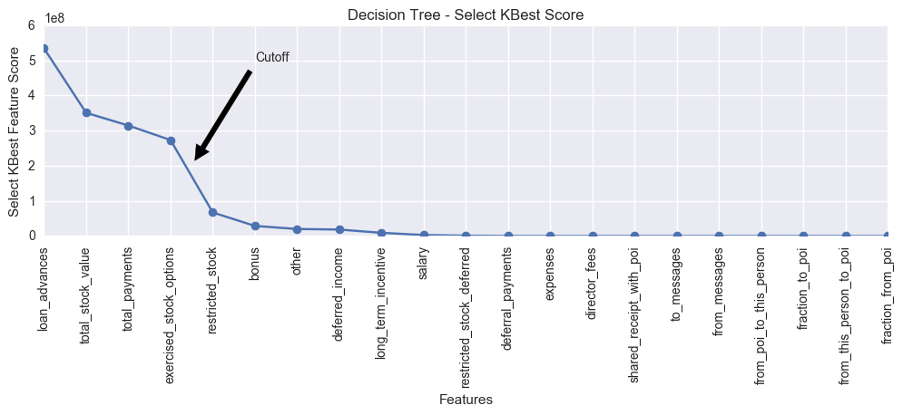

```python
xtick = results[2][4].index.values
x = [x for x in xrange(0,21)]

fig, axs = plt.subplots(1,1, figsize=(12,3))
axs.plot(x,results[2][4][0:]['score'], '-o')
axs.set_xticks(x)
axs.set_xticklabels(xtick, rotation=90)
axs.set_xlabel('Features')
axs.set_ylabel('Select KBest Feature Score')
axs.set_title('Decision Tree - Select KBest Score')
axs.annotate('Cutoff', xy=(3.5, 2e8), xytext=(5, 5e8),
            arrowprops=dict(facecolor='black', shrink=0.05))
```

This cutoff matches with Decision Tree Feature Importance table:

```python
print "Decision Tree - Feature Importance Table"

importances_table
```

```
Decision Tree - Feature Importance Table
```

| Feature | Importance Score |
| --- | --- |
| loan_advances | 0.614 |
| total_stock_value | 0.329 |
| total_payments | 0.056 |
| exercised_stock_options | 0.000 |

# 3. Pick and Tune an Algorithm

## 3.1 Pick an Algorithm

As Naive Bayes does not have parameters to tune, Decision Tree with second highest F1 score is selected as the final algorithm. Both algorithms met the precision and recall scores criteria of greater than 0.30.

F1 scoring metric is a better evaluation metric for this project because it measures accuracy using both precision and recall. F1 is the selected F-score subclass since algorithm passing criteria is having both precision and recall to be greater than 0.3 hence it is assumed that precision and recall are equally important. If the passing criteria was to weigh precision higher than recall or the other way around, F-score subclass of F0.5 or F2 would be chosen [https://en.wikipedia.org/wiki/F1_score].

The list and score summary of algorithms evaluated can be found in Feature Selection section.

## 3.2 Tune the Algorithm

Parameter tuning is a method of maximising algorithm performance by selecting the best parameters. The process in finding the optimum parameters is usually dependant on the data that the algorithms are deployed to, and requires a number of trials.

In this project, parameters tuning for each algorithms is done through GridSearchCV and it was cross validated as it goes. For the final algorithm, Decision Tree, the parameters tuned are as follows:

1. criterion: ('gini', 'entropy')
2. min_samples_split: [2, 5, 10, 15, 25, 50].

The parameters range was chosen based on their default values and some trials.

# 4. Validate and Evaluate

## 4.1 Validation and its Importance

Validation is the process of assessing how well the algorithm performs by separating data set into training set and test set. The algorithm is fitted on training set and the trained algorithm is then tested on test set to determine its performance. Cross validation is used to ensure the trained model generalizes well, without overfitting or underfitting. Cross validation performs the validation process multiple times, randomly splits data in each time.

In this project, 20 folds of stratified cross validation in random state was performed for grid search and a 1000 folds of stratified cross validation in random state was performed for evaluation. As the Enron dataset is a small and skewed dataset, cross validation is a better option.

## 4.2 Usage of Evaluation Metrics

As mentioned in previously, precision and recall are used as the evaluation metric in this project:

- Precision measures the ratio of POIs classified correctly to total number of predicted POIs.
- Recall measures the ratio of POIs classified correctly to total number of POIs.

Accuracy score measures the ratio of POIs and non-POIs classified correctly out of all data points. Enron dataset has 18 POIs and 128 non-POIs. Even if the identifier misses any POIs, the accuracy score would still be reasonably high hence accuracy score metric is not suitable for evaluating POI identifier.

## 4.3 Algorithm Performance

The chosen algorithm evaluated using tester.py also has precision and recall scores of greater than 0.3, this matches with cross validation result.

```python
clf_final = results[2][2]
final_features = ['poi'] + results[2][3]
test_classifier(clf_final, my_dataset, final_features)
```

```
Pipeline(steps=[('selectkbest', SelectKBest(k=4, score_func=<function chi2 at 0x08302570>)), ('decisiontreeclassifier', DecisionTreeClassifier(class_weight=None, criterion='entropy', max_depth=None,
            max_features=None, max_leaf_nodes=None,
            min_impurity_split=1e-07, min_samples_leaf=1,
            min_samples_split=10, min_weight_fraction_leaf=0.0,
            presort=False, random_state=42, splitter='best'))])
	Accuracy: 0.84320	Precision: 0.39398	Recall: 0.32700	F1: 0.35738	F2: 0.33851
	Total predictions: 15000	True positives:  654	False positives: 1006	False negatives: 1346	True negatives: 11994
```

# 5. References

- http://www.dataschool.io/comparing-supervised-learning-algorithms/
- https://mycourses.aalto.fi/pluginfile.php/393629/mod_resource/content/1/Lecture8.pdf
- http://scikit-learn.org/stable/modules/tree.html
- http://sebastianraschka.com/Articles/2014_about_feature_scaling.html
- https://stackoverflow.com/questions/27934885/how-to-hide-code-from-cells-in-ipython-notebook-visualized-with-nbviewer
- https://en.wikipedia.org/wiki/F1_score

# Honor Code Statement

“I, Dewi Octavia, hereby confirm that this submission is my work. I have cited above the origins of any parts of the submission that were taken from Websites, books, forums, blog posts, github repositories, etc. I understand that Udacity will check my submission for plagiarism, and that failure to adhere to the Udacity Honor Code may result in the cancellation of my enrollment."